# Week:3 Data pre-processing

### Objective:

The objective of this assignment is to perform exploratory data analysis, data pre-processing, data cleaning, scaling, transformation, check correlation between variables and perform sampling.

We use the Fatal Police Shooting data to answer the questions given in this notebook.

### Fatal Police Shooting Data

**About dataset**  
The dataset consists of following columns

1. **id** : unqiue identifier of each victim
2. **name** : name of a victim
3. **date** : date on fatal shooting
4. **manner_of_death** : manner of death classification
   - Shot
   - Shot and Tasered
5. **armed** : indicates that the victim was armed with some sort of implement that a police officer believed could inflict harm
   - undetermined: it is not known whether or not the victim had a weapon
   - unknown: the victim was armed, but it is not known what the object was
   - unarmed: the victim was not armed
6. **age** : age of victim
7. **gender** : the gender of the victim. The Post identifies victims by the gender they identify with if reports indicate that it differs from their biological sex.
   - M: Male
   - F: Female
   - None: Unknown
8. **race** : race of victim
   - W: White, non-Hispanic
   - B: Black, non-Hispanic
   - A: Asian
   - N: Native American
   - H: Hispanic
   - O: Other
   - None: unknown
9. **city** : the municipality where the fatal shooting took place. Note that in some cases this field may contain a county name if a more specific municipality is unavailable or unknown.
10. **state** : two-letter postal code abbreviation
11. **signs_of_mental_illness** : News reports have indicated the victim had a history of mental health issues, expressed suicidal intentions or was experiencing mental distress at the time of the shooting.
12. **threat_level** : These would include incidents where officers or others were shot at, threatened with a gun, attacked with other weapons or physical force, etc. The attack category is meant to flag the highest level of threat. The other and undetermined categories represent all remaining cases. Other includes many incidents where officers or others faced significant threats.
13. **flee** : News reports have indicated the victim was moving away from officers
    - Foot
    - Car
    - Not fleeing
14. **body_camera** : News reports have indicated an officer was wearing a body camera and it may have recorded some portion of the incident.

## Let's Begin

```python
# Install the libraries
import pandas as pd
import numpy as np
import matplotlib.pyplot as plt
import seaborn as sns
%matplotlib inline
```

```python
# Load the dataframe
df = pd.read_csv('./week_2_assignment_output.csv')
df.head()

# TODO: Code to fill:
# 1. '<<__A__>>' --> Path of the csv file
```

|  | id | name | date | manner_of_death | armed | age | gender | race | city | state | signs_of_mental_illness | threat_level | flee | body_camera | age_categories | year |
| --- | --- | --- | --- | --- | --- | --- | --- | --- | --- | --- | --- | --- | --- | --- | --- | --- |
| 0 | 3 | Tim Elliot | 2015-01-02 | shot | gun | 53.0 | M | A | Shelton | WA | True | attack | Not fleeing | False | Senior citizens | 2015 |
| 1 | 4 | Lewis Lee Lembke | 2015-01-02 | shot | gun | 47.0 | M | W | Aloha | OR | False | attack | Not fleeing | False | Adult | 2015 |
| 2 | 5 | John Paul Quintero | 2015-01-03 | shot and Tasered | unarmed | 23.0 | M | H | Wichita | KS | False | other | Not fleeing | False | Youth | 2015 |
| 3 | 8 | Matthew Hoffman | 2015-01-04 | shot | toy weapon | 32.0 | M | W | San Francisco | CA | True | attack | Not fleeing | False | Youth | 2015 |
| 4 | 9 | Michael Rodriguez | 2015-01-04 | shot | nail gun | 39.0 | M | H | Evans | CO | False | attack | Not fleeing | False | Adult | 2015 |

```python
# Check the shape of the dataset
df.shape
```

```
(4478, 16)
```

### Question: 1 ( 1 Mark )

Check and Handle the missing values (NaN) present in each column with the respective methods

```python
df.info()
```

```
<class 'pandas.core.frame.DataFrame'>
RangeIndex: 4478 entries, 0 to 4477
Data columns (total 16 columns):
 #   Column                   Non-Null Count  Dtype
---  ------                   --------------  -----
 0   id                       4478 non-null   int64
 1   name                     4478 non-null   object
 2   date                     4478 non-null   object
 3   manner_of_death          4478 non-null   object
 4   armed                    4230 non-null   object
 5   age                      4309 non-null   float64
 6   gender                   4473 non-null   object
 7   race                     4105 non-null   object
 8   city                     4478 non-null   object
 9   state                    4478 non-null   object
 10  signs_of_mental_illness  4478 non-null   bool
 11  threat_level             4478 non-null   object
 12  flee                     4299 non-null   object
 13  body_camera              4478 non-null   bool
 14  age_categories           4478 non-null   object
 15  year                     4478 non-null   int64
dtypes: bool(2), float64(1), int64(2), object(11)
memory usage: 498.7+ KB
```

```python
# Check the dataframe for missing values in the column before handling
df.isnull().sum()

# TODO: Code to fill:

# 1. '<<__A__>>' --> Use correct method
# 2. '<<__B__>>' --> Use correct method
```

```
id                           0
name                         0
date                         0
manner_of_death              0
armed                      248
age                        169
gender                       5
race                       373
city                         0
state                        0
signs_of_mental_illness      0
threat_level                 0
flee                       179
body_camera                  0
age_categories               0
year                         0
dtype: int64
```

```python
print(df.armed.value_counts())
print(df.age.value_counts())
print(df.gender.value_counts())
print(df.race.value_counts())
print(df.flee.value_counts())
```

```
armed
gun                2489
knife               674
unarmed             288
undetermined        175
toy weapon          158
                   ...
bow and arrow         1
vehicle and gun       1
wrench                1
walking stick         1
barstool              1
Name: count, Length: 84, dtype: int64
age
25.0    163
33.0    145
27.0    143
32.0    142
29.0    141
       ...
13.0      1
79.0      1
91.0      1
78.0      1
89.0      1
Name: count, Length: 77, dtype: int64
gender
M    4265
F     208
Name: count, dtype: int64
race
W    2059
B    1072
H     786
A      76
N      72
O      40
Name: count, dtype: int64
flee
Not fleeing    2868
Car             729
Foot            566
Other           136
Name: count, dtype: int64
```

```python
print('Armed', df.armed.unique())
print('Age', df.age.unique())
print('Gender', df.gender.unique())
print('Race', df.race.unique())
print('Flee', df.flee.unique())
```

```
Armed ['gun' 'unarmed' 'toy weapon' 'nail gun' 'knife' nan 'shovel' 'hammer'
 'hatchet' 'undetermined' 'sword' 'machete' 'box cutter' 'metal object'
 'screwdriver' 'lawn mower blade' 'flagpole' 'guns and explosives'
 'cordless drill' 'crossbow' 'metal pole' 'Taser' 'metal pipe'
 'metal hand tool' 'blunt object' 'metal stick' 'sharp object'
 'meat cleaver' 'carjack' 'chain' "contractor's level" 'unknown weapon'
 'stapler' 'beer bottle' 'bean-bag gun' 'baseball bat and fireplace poker'
 'straight edge razor' 'gun and knife' 'ax' 'brick' 'baseball bat'
 'hand torch' 'chain saw' 'garden tool' 'scissors' 'pole' 'pick-axe'
 'flashlight' 'baton' 'spear' 'chair' 'pitchfork' 'hatchet and gun' 'rock'
 'piece of wood' 'bayonet' 'pipe' 'glass shard' 'motorcycle'
 'pepper spray' 'metal rake' 'crowbar' 'oar' 'machete and gun' 'tire iron'
 'air conditioner' 'pole and knife' 'baseball bat and bottle' 'fireworks'
 'pen' 'chainsaw' 'gun and sword' 'gun and car' 'vehicle' 'pellet gun'
 'claimed to be armed' 'BB gun' 'incendiary device' 'samurai sword'
 'bow and arrow' 'gun and vehicle' 'vehicle and gun' 'wrench'
 'walking stick' 'barstool']
Age [53. 47. 23. 32. 39. 18. 22. 35. 34. 25. 31. 41. 30. 37. 28. 42. 36. 49.
 71. 33. 29. 43. 24. 75. 68. 27. 48. 21. 67. 19. 54. 17. 61. 56. 40. 45.
 26. 59. 38. 51. 74. 57. 46. 16. 50. 20. nan 77. 58. 64. 52. 63. 44. 60.
 66. 83. 72. 76. 62. 55. 69. 86. 15. 65.  6. 12. 70. 80. 14. 82. 13. 73.
 91. 79. 78. 84. 81. 89.]
Gender ['M' 'F' nan]
Race ['A' 'W' 'H' 'B' 'O' nan 'N']
Flee ['Not fleeing' 'Car' 'Foot' 'Other' nan]
```

```python
nan_columns = ['armed', 'age', 'gender', 'race', 'flee']
df[nan_columns].describe(include='all').T
```

|  | count | unique | top | freq | mean | std | min | 25% | 50% | 75% | max |
| --- | --- | --- | --- | --- | --- | --- | --- | --- | --- | --- | --- |
| armed | 4230 | 84 | gun | 2489 | NaN | NaN | NaN | NaN | NaN | NaN | NaN |
| age | 4309.0 | NaN | NaN | NaN | 36.879322 | 13.067598 | 6.0 | 27.0 | 35.0 | 45.0 | 91.0 |
| gender | 4473 | 2 | M | 4265 | NaN | NaN | NaN | NaN | NaN | NaN | NaN |
| race | 4105 | 6 | W | 2059 | NaN | NaN | NaN | NaN | NaN | NaN | NaN |
| flee | 4299 | 4 | Not fleeing | 2868 | NaN | NaN | NaN | NaN | NaN | NaN | NaN |

```python
# Handle the missing values for all the columns:

# Handle the missing values for the 'armed' column
# Use mode ('most frequent' value) as a reasonable default value for categorical data
df['armed'] = df['armed'].fillna(df['armed'].mode()[0])

# write your code here to handle missing values for other columns

# Handle the missing values for the 'age' column
# Since 'age' is numerical and right-skewed, using the median is more appropriate than the mean
df['age'] = df['age'].fillna(df['age'].median())

# Handle the missing values for the 'gender' column
# Use mode (most frequent gender, likely 'male')
df['gender'] = df['gender'].fillna(df['gender'].mode()[0])

# Handle the missing values for the 'race' column
# Use 'N' (None) or 'O' (Other) as a placeholder where race is unknown or unspecified
df['race'] = df['race'].fillna('N')

# Handle the missing values for the 'flee' column
# Since "Not Fleeing" is likely the most common value, use the mode
df['flee'] = df['flee'].fillna(df['flee'].mode()[0])

# TODO: Code to fill:

# 1. '<<__A__>>' --> Appropriate filling method
# 2. '<<__B__>>' --> column_name
# 3. '<<__C__>>' --> column_name
```

```python
# Check dataframe after handling missing values
df.isnull().sum()

# TODO: Code to fill:

# 1. '<<__A__>>' --> Use correct method
# 2. '<<__B__>>' --> Use correct method
```

```
id                         0
name                       0
date                       0
manner_of_death            0
armed                      0
age                        0
gender                     0
race                       0
city                       0
state                      0
signs_of_mental_illness    0
threat_level               0
flee                       0
body_camera                0
age_categories             0
year                       0
dtype: int64
```

```python
df[nan_columns].describe(include='all').T
```

|  | count | unique | top | freq | mean | std | min | 25% | 50% | 75% | max |
| --- | --- | --- | --- | --- | --- | --- | --- | --- | --- | --- | --- |
| armed | 4478 | 84 | gun | 2737 | NaN | NaN | NaN | NaN | NaN | NaN | NaN |
| age | 4478.0 | NaN | NaN | NaN | 36.808397 | 12.823588 | 6.0 | 27.0 | 35.0 | 45.0 | 91.0 |
| gender | 4478 | 2 | M | 4270 | NaN | NaN | NaN | NaN | NaN | NaN | NaN |
| race | 4478 | 6 | W | 2059 | NaN | NaN | NaN | NaN | NaN | NaN | NaN |
| flee | 4478 | 4 | Not fleeing | 3047 | NaN | NaN | NaN | NaN | NaN | NaN | NaN |

### Question: 2 (1 Mark )

Handle the outliers present in the age column

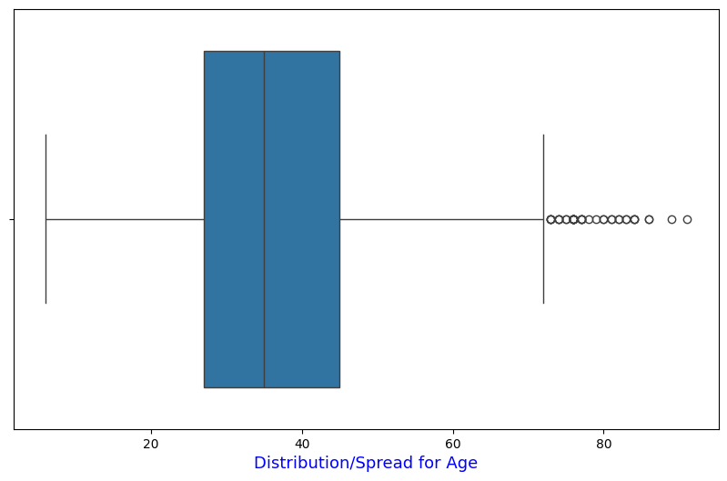

```python
# Display the box plot before handling outliers in the age column
plt.figure(figsize=(10,6))
sns.boxplot(data=df, x='age')

# Add some visual customizations
plt.xlabel('Distribution/Spread for Age', color='blue',fontsize=13)
plt.show()

# TODO: Code to fill:

# 1. '<<__A__>>' --> Display the box plot before handling outliers in the age column
```

#### The mean is slightly greater than median and there is right skewness in the data due to these outliers on the right side of the 1.5 * IQR range. Hence we will remove those.

```python
# Quantile 1 of age column (25 percentage)
Q1 = df['age'].quantile(0.25)
# Quantile 3 of age column (75 percentage)
Q3 = df['age'].quantile(0.75)
```

```python
# Inter Quartile Range
IQR = Q3 - Q1
IQR

print(f'Q3={Q3}, Q1={Q1}, IQR={IQR}')
```

```
Q3=45.0, Q1=27.0, IQR=18.0
```

```python
# Outliers present in upper case
upper_case = Q3 + (1.5*IQR)
print('Upper Bound =', upper_case)
# Outliers present in lower case
lower_case = Q1 - (1.5*IQR)
print('Lower Bound =', lower_case)
```

```
Upper Bound = 72.0
Lower Bound = 0.0
```

```python
# Print outliers in the age column
outliers = []
for age in df['age']:
    if age < lower_case or age > upper_case:
        outliers.append(age)
print(np.sort(outliers))
```

```
[73. 73. 73. 73. 74. 74. 74. 75. 75. 76. 76. 76. 76. 76. 76. 76. 76. 76.
 77. 77. 77. 77. 78. 79. 80. 80. 81. 81. 82. 82. 83. 83. 84. 84. 84. 86.
 86. 89. 91.]
```

#### Another option to display the outlier is using the following code

```
# Another option to print outliers using data frame filters
outliers = df[(df['age'] <  lower_case) | (df['age'] > upper_case)]
print(outliers['age'].reset_index(drop=True).describe().T)
print(np.sort(outliers['age'].reset_index(drop=True).to_numpy()))
```

```python
# Remove the outliers in age column
# using np.clip, this will not introduce nulls
df['age'] = np.clip(df['age'], lower_case, upper_case)

# TODO: Code to fill:

# 1. '<<__B__>>' --> write the your command to remove outliers outside upper case and lower case
```

#### As per the question format and the explanation given in FAQs, we are required to remove the outliers from df['age'] columns only and save the values to df['age'] again. np.clip infact normalize the outlier within a given lower and upper bound. Using np.clip will overcome the issue of having nulls in the age column if we otherwise choose to drop the outliers entries. Below example code we have 2 other options to handle the outliers with certain consequences. Droping only values from age column will introduce nulls in this field and removing the whole rows of outliers will cause data loss for other attributes. Hence np.clip is a better option but it'll introduce biaseness in data.

```
# Filter the dataframe rows, removing the rows where age is an outlier
# This will result in dataloss for other features which are not outliers
df = df[(df['age'] >= lower_case) & (df['age'] <= upper_case)]

# Another Option is to drop only the values from age column. This will introduce Null values in age column
df['age'] = df['age'].where((df['age'] >= lower_case) & (df['age'] <= upper_case))

# Hence np.clip is a better option
```

```python
# We can check that outliers are clip to upper bound which is 72 and no nulls were included
df['age'].describe()
```

```
count    4478.000000
mean       36.750112
std        12.639778
min         6.000000
25%        27.000000
50%        35.000000
75%        45.000000
max        72.000000
Name: age, dtype: float64
```

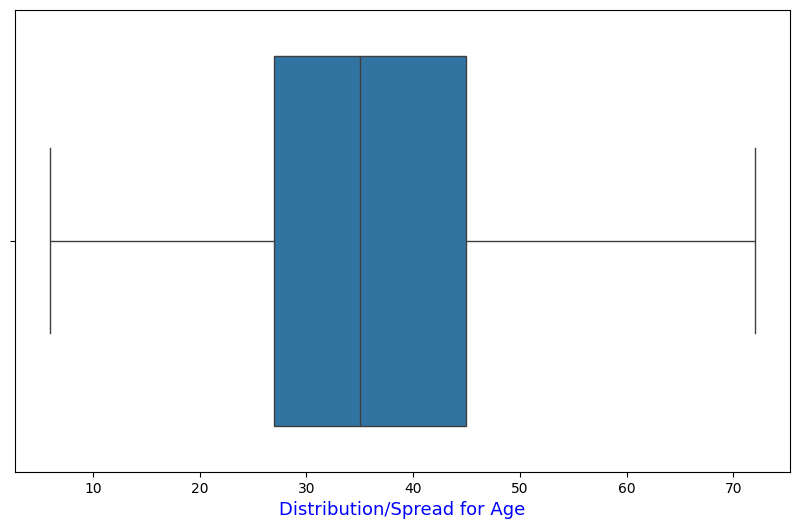

```python
# Display the box plot after handling outliers in the age column
plt.figure(figsize=(10,6))
sns.boxplot(data=df, x='age')

# Add some visual customizations
plt.xlabel('Distribution/Spread for Age', color='blue',fontsize=13)
plt.show()

# TODO: Code to fill:

# 1  '<<__C__>>' --> Display the box plot after handling outliers in the age column
```

#### We have successfully removed the outliers from age column, as can be observed in the above box plot. Median remain uneffected while mean got slight adjustment after removing outliers.

### Question: 3 ( 1 Mark )

Plot a bar graph which tells most repeated weapons used to attack the people

```python
df['armed'].unique()
```

```
array(['gun', 'unarmed', 'toy weapon', 'nail gun', 'knife', 'shovel',
       'hammer', 'hatchet', 'undetermined', 'sword', 'machete',
       'box cutter', 'metal object', 'screwdriver', 'lawn mower blade',
       'flagpole', 'guns and explosives', 'cordless drill', 'crossbow',
       'metal pole', 'Taser', 'metal pipe', 'metal hand tool',
       'blunt object', 'metal stick', 'sharp object', 'meat cleaver',
       'carjack', 'chain', "contractor's level", 'unknown weapon',
       'stapler', 'beer bottle', 'bean-bag gun',
       'baseball bat and fireplace poker', 'straight edge razor',
       'gun and knife', 'ax', 'brick', 'baseball bat', 'hand torch',
       'chain saw', 'garden tool', 'scissors', 'pole', 'pick-axe',
       'flashlight', 'baton', 'spear', 'chair', 'pitchfork',
       'hatchet and gun', 'rock', 'piece of wood', 'bayonet', 'pipe',
       'glass shard', 'motorcycle', 'pepper spray', 'metal rake',
       'crowbar', 'oar', 'machete and gun', 'tire iron',
       'air conditioner', 'pole and knife', 'baseball bat and bottle',
       'fireworks', 'pen', 'chainsaw', 'gun and sword', 'gun and car',
       'vehicle', 'pellet gun', 'claimed to be armed', 'BB gun',
       'incendiary device', 'samurai sword', 'bow and arrow',
       'gun and vehicle', 'vehicle and gun', 'wrench', 'walking stick',
       'barstool'], dtype=object)
```

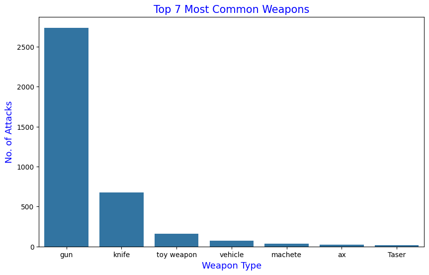

```python
# Get the value count of armed column
# Exclude unarmed or where armed type is non deterministic,
# Since these are not valid arm types
armed = df[df['armed'].isin(
    ['unarmed', 'undetermined', 'unknown weapon']
) == False].armed.value_counts()
# set the plot size
plt.figure(figsize=(10,6))
# Create a bar plot using above variable by filtering upto 7 rows
sns.barplot(x=armed[:7].index,y=armed[:7].values)

# Add some visual customizations
#plt.grid(axis='y')
plt.ylabel('No. of Attacks', color = 'blue',fontsize=13)
plt.xlabel('Weapon Type', color = 'blue',fontsize=13)
plt.title('Top 7 Most Common Weapons', color = 'blue',fontsize=15)
plt.show()

# TODO: Code to fill:

# 1. '<<__A__>>' --> Set the plot size
# 2. '<<__B__>>' --> set a name for y label
# 3. '<<__C__>>' --> set a name for x label
# 4. '<<__D__>>' --> set a title for the graph with a  fontsize 15 in the colour of blue
```

#### The top 7 most repeated weapons used as per our data are depicted in the above bar plot. We can see the most number of attacks are conducted using a gun, followed by knife. However the preferred obvious leading weapon in this data is a gun.

### Question: 4 ( 2 Marks )

Generate a bar plot to identify days in which the count of attacks are reported most

```python
# Create a new columns day, month, year using date column with the help of pandas to_datetime method
df['day'] = pd.to_datetime(df['date']).dt.day
df['month'] = pd.to_datetime(df['date']).dt.month
# We already have year column from week 2 so we can skip year computation as well if we want.
df['year'] = pd.to_datetime(df['date']).dt.year
```

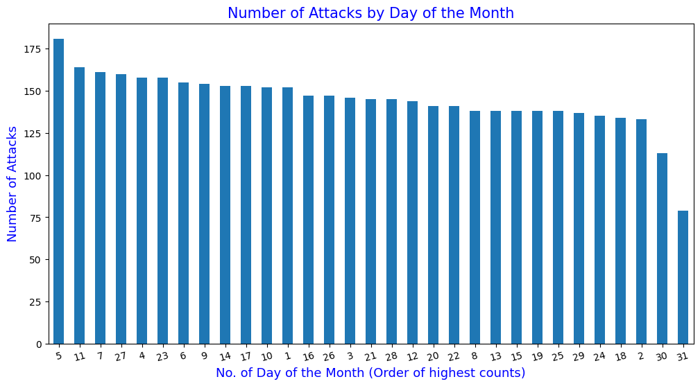

```python
#Plot a bar graph in which days the count of attcks are more
df['day'].value_counts().plot.bar(figsize=(12, 6))

# Add some visual customizations
#plt.grid(axis='y')
plt.xlabel('No. of Day of the Month (Order of highest counts)', color = 'blue',fontsize=13)
plt.xticks(rotation=15)
plt.ylabel('Number of Attacks', color = 'blue',fontsize=13)
plt.title('Number of Attacks by Day of the Month', color = 'blue',fontsize=15)
plt.show()

# TODO: Code to fill:

# 1. '<<__A__>>' --> Fill the column name for which you want to plot a bar graph
# 2. '<<__B__>>' --> write your method here to count the values
# 3. '<<__C__>>' --> fill the type of plot
# 4. '<<__D__>>' --> Set plot size (12,6)
```

#### Distribution of Attack Counts by Day of the Month, Sorted by Highest Count Days First. This bar plot shows the number of attacks that occurred on each day of the month, with days arranged in descending order by frequency. The x-axis represents the day of the month, while the y-axis shows the total number of attacks. This visualization helps identify which specific days of month had a higher frequency of attacks, providing insights into possible patterns or anomalies on certain dates.

### Question: 5 ( 2 Marks )

Display the Top 10 states where the high number of cases recorded

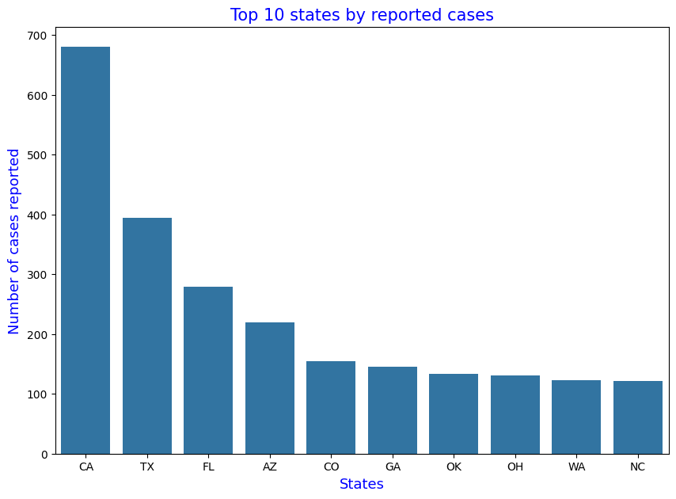

```python
# Write your code here
state = df['state'].value_counts()

# Display the Top 10 states using bar chart
plt.figure(figsize=(10,7))
sns.barplot(x=state[:10].index, y=state[:10].values)

# Add some visual customizations
plt.ylabel('Number of cases reported',color = 'blue',fontsize=13)
plt.xlabel('States',color = 'blue',fontsize=13)
plt.title('Top 10 states by reported cases',color = 'blue',fontsize=15)


# TODO: Code to fill:

# 1. '<<__A__>>' --> Fill the column name
# 2. '<<__B__>>' --> write your method here to count the values
# 3. '<<__C__>>' --> Provide x axis values from state dataframe created in previous step
# 4. '<<__D__>>' --> Provide y axis values from state dataframe created in previous step
```

#### Top 10 States with the Highest Number of Reported Cases. This bar chart displays the states with the most recorded cases, highlighting the top 10 states in descending order of case counts. The x-axis lists the states, while the y-axis represents the number of cases reported in each state. This visualization provides a quick view of regional case distribution, allowing for easy comparison among the states with the highest incidence rates.

### Question: 6 ( 1 Mark )

Drop the features that have more unique string values and not relevant to the model.

```python
df.head()
```

|  | id | name | date | manner_of_death | armed | age | gender | race | city | state | signs_of_mental_illness | threat_level | flee | body_camera | age_categories | year | day | month |
| --- | --- | --- | --- | --- | --- | --- | --- | --- | --- | --- | --- | --- | --- | --- | --- | --- | --- | --- |
| 0 | 3 | Tim Elliot | 2015-01-02 | shot | gun | 53.0 | M | A | Shelton | WA | True | attack | Not fleeing | False | Senior citizens | 2015 | 2 | 1 |
| 1 | 4 | Lewis Lee Lembke | 2015-01-02 | shot | gun | 47.0 | M | W | Aloha | OR | False | attack | Not fleeing | False | Adult | 2015 | 2 | 1 |
| 2 | 5 | John Paul Quintero | 2015-01-03 | shot and Tasered | unarmed | 23.0 | M | H | Wichita | KS | False | other | Not fleeing | False | Youth | 2015 | 3 | 1 |
| 3 | 8 | Matthew Hoffman | 2015-01-04 | shot | toy weapon | 32.0 | M | W | San Francisco | CA | True | attack | Not fleeing | False | Youth | 2015 | 4 | 1 |
| 4 | 9 | Michael Rodriguez | 2015-01-04 | shot | nail gun | 39.0 | M | H | Evans | CO | False | attack | Not fleeing | False | Adult | 2015 | 4 | 1 |

```python
df.info()
```

```
<class 'pandas.core.frame.DataFrame'>
RangeIndex: 4478 entries, 0 to 4477
Data columns (total 18 columns):
 #   Column                   Non-Null Count  Dtype
---  ------                   --------------  -----
 0   id                       4478 non-null   int64
 1   name                     4478 non-null   object
 2   date                     4478 non-null   object
 3   manner_of_death          4478 non-null   object
 4   armed                    4478 non-null   object
 5   age                      4478 non-null   float64
 6   gender                   4478 non-null   object
 7   race                     4478 non-null   object
 8   city                     4478 non-null   object
 9   state                    4478 non-null   object
 10  signs_of_mental_illness  4478 non-null   bool
 11  threat_level             4478 non-null   object
 12  flee                     4478 non-null   object
 13  body_camera              4478 non-null   bool
 14  age_categories           4478 non-null   object
 15  year                     4478 non-null   int32
 16  day                      4478 non-null   int32
 17  month                    4478 non-null   int32
dtypes: bool(2), float64(1), int32(3), int64(1), object(11)
memory usage: 516.1+ KB
```

```python
# Select object and int64 (id) columns
object_cols = df.select_dtypes(include=['int64', 'object'])

# Find the unique value counts for each non-numeric column
unique_counts = {col: df[col].nunique() for col in object_cols.columns}

# Display the unique counts
unique_counts
```

```
{'id': 4478,
 'name': 4332,
 'date': 1551,
 'manner_of_death': 2,
 'armed': 84,
 'gender': 2,
 'race': 6,
 'city': 2168,
 'state': 51,
 'threat_level': 3,
 'flee': 4,
 'age_categories': 5}
```

**id:** The id column is a unique identifier for each row, but it has no impact on our current KDD excercise. Since each value is unique, it doesn’t provide any meaningful pattern or trend that could help in predictions. Including it would only add noise to the model.

**name:** The name column is typically a text field that uniquely identifies individuals or entities but does not provide generalizable information useful for extracting patterns.

**date:** The date column might contain temporal information, but in many cases, it can be decomposed into more relevant features (e.g., day, month, year). If the exact date itself is not relevant for the model, it can be excluded. Since we already extracted day, month and year, we can get rid of date column.

Dropping these columns simplifies the dataset, reduces dimensionality, and helps focus the model on features that are more likely to provide predictive insights.

```python
# Drop the features that have more unique string values and not relevant to the model.
df.drop(columns=['id', 'name', 'date'], axis=1, inplace=True)
```

```python
#Display the top 5 rows of dataset after droping the unnecessary features
df.head(5)

# TODO: Code to fill:

# 1. '<<__A__>>' --> Fill appropriate method for removing features
# 2. '<<__B__>>' --> column names
# 3. '<<__C__>>' --> Give the axis for removing features
# 3. '<<__D__>>' --> Use the correct method to get top 5 rows of dataset after droping the unnessacary features
```

|  | manner_of_death | armed | age | gender | race | city | state | signs_of_mental_illness | threat_level | flee | body_camera | age_categories | year | day | month |
| --- | --- | --- | --- | --- | --- | --- | --- | --- | --- | --- | --- | --- | --- | --- | --- |
| 0 | shot | gun | 53.0 | M | A | Shelton | WA | True | attack | Not fleeing | False | Senior citizens | 2015 | 2 | 1 |
| 1 | shot | gun | 47.0 | M | W | Aloha | OR | False | attack | Not fleeing | False | Adult | 2015 | 2 | 1 |
| 2 | shot and Tasered | unarmed | 23.0 | M | H | Wichita | KS | False | other | Not fleeing | False | Youth | 2015 | 3 | 1 |
| 3 | shot | toy weapon | 32.0 | M | W | San Francisco | CA | True | attack | Not fleeing | False | Youth | 2015 | 4 | 1 |
| 4 | shot | nail gun | 39.0 | M | H | Evans | CO | False | attack | Not fleeing | False | Adult | 2015 | 4 | 1 |

### Question: 7 ( 2 Marks )

Create a line plot that shows the number of attacks every year according to race

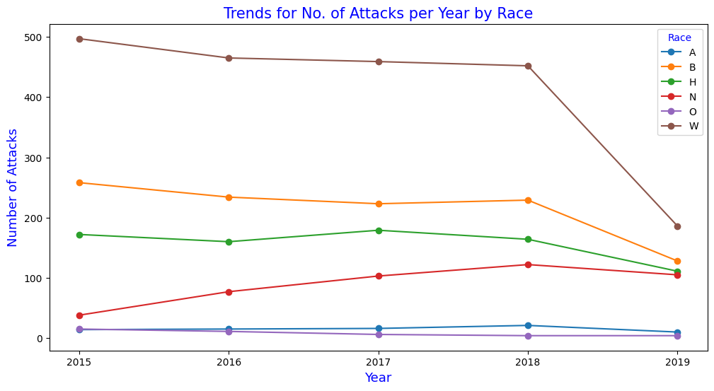

```python
# Write your code here
# Add a marker for better visibility
pd.crosstab(df['year'], df['race']).plot.line(figsize=(12,6), marker='o')

# Add some visual customizations
# Set x-ticks to the unique years in the dataset
plt.xticks(ticks=df['year'].unique(), labels=df['year'].unique())
#plt.grid(axis='x')
plt.xlabel('Year',color = 'blue',fontsize=13)
plt.ylabel('Number of Attacks',color = 'blue',fontsize=13)
plt.title('Trends for No. of Attacks per Year by Race',color = 'blue',fontsize=15)
legend = plt.legend(title='Race')
legend.get_title().set_color('blue')

plt.show()
# TODO: Code to fill:

# 1. '<<__A__>>' --> Fill the exact column name
# 2. '<<__B__>>' --> Fill the exact column name
```

#### Annual Trend of Attacks by Race. This line plot shows the number of recorded attacks each year, categorized by race. Each line represents a different racial group, with markers highlighting the yearly data points. The x-axis represents the years, while the y-axis displays the total number of attacks for each racial group. This visualization helps reveal trends over time, showing fluctuations and any significant changes in attack counts for each racial group.

```python
# Save the output to a csv file
df.to_csv('week_3_assignment_output.csv', index=False)
```